# CS109 Final Project: Take One

```python
clfTree2 = tree.DecisionTreeClassifier()
clfTree2, Xtrain, ytrain, Xtest, ytest=do_classify(clfTree2, parameters_tree, dftouse, Xnames,
                                                 'adj_opening_gross_bin', 1, mask=mask_classify)
```

```
using mask
BEST {'max_depth': 1, 'min_samples_leaf': 1} 0.89898989899 [mean: 0.89899, std: 0.05400, params: {'max_depth': 1, 'min_samples_leaf': 1}, mean: 0.89899, std: 0.05400, params: {'max_depth': 1, 'min_samples_leaf': 2}, mean: 0.89899, std: 0.05400, params: {'max_depth': 1, 'min_samples_leaf': 3}, mean: …
############# based on standard predict ################
Accuracy on training data: 0.90
Accuracy on test data:     0.80
[[61 21]
 [ 6 45]]
########################################################
```

```python
from sklearn.ensemble import RandomForestClassifier

clfforest1 = RandomForestClassifier()

parameters_forest = {"n_estimators": range(1, len(Xnames))}
clfforest1, Xtrain, ytrain, Xtest, ytest = do_classify(clfforest1, parameters_forest,
                                                       dftouse, Xnames, 'adj_opening_gross_bin', 1, mask=mask_classify)
```

```
using mask
BEST {'n_estimators': 6} 0.848484848485 [mean: 0.77778, std: 0.07489, params: {'n_estimators': 1}, mean: 0.78283, std: 0.01723, params: {'n_estimators': 2}, mean: 0.82323, std: 0.02912, params: {'n_estimators': 3}, mean: 0.81818, std: 0.02862, params: {'n_estimators': 4}, mean: 0.83838, std: 0.04494…
############# based on standard predict ################
Accuracy on training data: 0.98
Accuracy on test data:     0.77
[[68 14]
 [16 35]]
########################################################
```

```python
clfforest2 = RandomForestClassifier()

parameters_forest = {"n_estimators": range(1, len(Xnames))}
clfforest2, Xtrain, ytrain, Xtest, ytest = do_classify(clfforest2, parameters_forest,
                                                       dftouse, Xnames, 'adj_opening_gross_bin', 1, mask=mask_classify)
```

```
using mask
BEST {'n_estimators': 5} 0.863636363636 [mean: 0.82323, std: 0.03897, params: {'n_estimators': 1}, mean: 0.77778, std: 0.02852, params: {'n_estimators': 2}, mean: 0.84343, std: 0.04774, params: {'n_estimators': 3}, mean: 0.80303, std: 0.03014, params: {'n_estimators': 4}, mean: 0.86364, std: 0.04151…
############# based on standard predict ################
Accuracy on training data: 0.98
Accuracy on test data:     0.76
[[66 16]
 [16 35]]
########################################################
```

```python
from sklearn.ensemble import AdaBoostClassifier

clfAda1 = AdaBoostClassifier()

parameters_adaboost = {"n_estimators": range(10, 60)}
clfAda1, Xtrain, ytrain, Xtest, ytest = do_classify(clfAda1, parameters_adaboost,
                                                       dftouse, two_features, 'adj_opening_gross_bin',
                                                   1, mask=mask_classify)
```

[output not shown]

```python
clfAda2 = AdaBoostClassifier()

parameters_adaboost = {"n_estimators": range(10, 60)}
clfAda2, Xtrain, ytrain, Xtest, ytest = do_classify(clfAda2, parameters_adaboost,
                                                       dftouse, Xnames, 'adj_opening_gross_bin',
                                                   1, mask=mask_classify)
```

[output not shown]

```python
from sklearn.ensemble import GradientBoostingClassifier

clfGB = GradientBoostingClassifier()

parameters_GB = {"n_estimators": range(30, 60), "max_depth": [1, 2, 3, 4, 5]}
clfGB, Xtrain, ytrain, Xtest, ytest = do_classify(clfGB, parameters_GB,
                                                       dftouse, two_features, 'adj_opening_gross_bin', 1
                                                  , mask=mask_classify)
```

[output not shown]

```python
clfGB2 = GradientBoostingClassifier()

parameters_GB = {"n_estimators": range(30, 60), "max_depth": [1, 2, 3, 4, 5]}
clfGB2, Xtrain, ytrain, Xtest, ytest = do_classify(clfGB2, parameters_GB,
                                                       dftouse, Xnames, 'adj_opening_gross_bin', 1
                                                  , mask=mask_classify)
```

[output not shown]

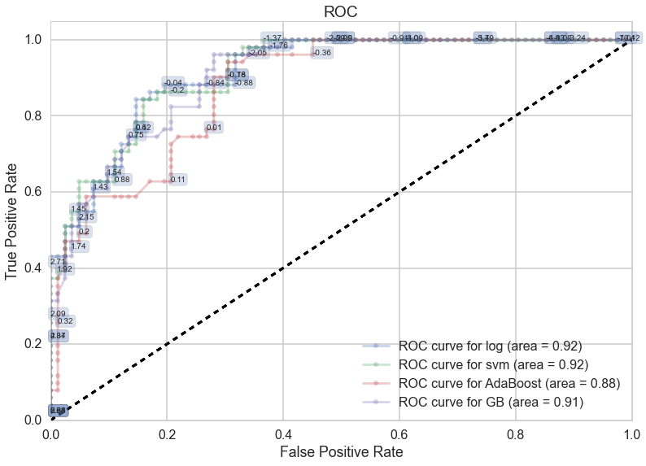

```python
ax1=make_roc("log", clflog2, ytest, Xtest, labe=10, proba=False)
ax1=make_roc("svm", clfsvm2, ytest, Xtest, labe=10, proba=False)
ax1=make_roc("AdaBoost", clfAda2, ytest, Xtest, labe=10, proba=False)
ax1=make_roc("GB", clfGB2, ytest, Xtest, labe=10, proba=False)
```

```python
from sklearn.tree import DecisionTreeClassifier
import sklearn.linear_model
import sklearn.svm

def plot_decision_surface(clf, X_train, Y_train):
    plot_step=0.1

    if X_train.shape[1] != 2:
        raise ValueError("X_train should have exactly 2 columnns!")

    x_min, x_max = X_train[:, 0].min() - plot_step, X_train[:, 0].max() + plot_step
    y_min, y_max = X_train[:, 1].min() - plot_step, X_train[:, 1].max() + plot_step
    xx, yy = np.meshgrid(np.arange(x_min, x_max, plot_step),
                         np.arange(y_min, y_max, plot_step))

    clf.fit(X_train,Y_train)
    if hasattr(clf, 'predict_proba'):
        Z = clf.predict_proba(np.c_[xx.ravel(), yy.ravel()])[:,1]
    else:
        Z = clf.predict(np.c_[xx.ravel(), yy.ravel()])
    Z = Z.reshape(xx.shape)
    cs = plt.contourf(xx, yy, Z, cmap=plt.cm.Reds)
    plt.scatter(X_train[:,0],X_train[:,1],c=Y_train,cmap=plt.cm.Paired)
    plt.show()

# your code here
imp_cols = clfforest2.feature_importances_.argsort()[::-1][0:2]
```

# This cell of code broke my kernel!

```python
X_imp = dftouse[imp_cols].values

for i in X_imp:
    for p in i:
        i[p] = int(i[p])

Y = dftouse.adj_opening_gross_bin.values
name_list = dftouse.columns

classifiers = [clfTree2,
               clfForest,
               clfAda,
               clfGB,
               sklearn.svm.SVC(C=100.0, gamma=1.0)]

titleClassifer = ['Decision Tree Classifier', 'Random Forest Classifier',
                  'AdaBoost Classifier', 'Gradient Boosting Classifier', 'Support Vector Machine']
for c in xrange(5):
    plt.title(titleClassifer[c])
    plt.xlabel(name_list[0])
    plt.ylabel(name_list[1])
    plot_decision_surface(classifiers[c], X_imp, dftouse.adj_opening_gross_bin.values)
```

# Conclude analysis and introduce next Phase of Project

At the end of our analysis, we reached the following conclusions:

- We were unable to realize any significant relationship between our variables of interest (viewer sentiment and box office success).
- Hence, we should collect more data by scraping from more sources, since we had less than 400 data points for the analyses above. We hope that having more data will help to see the relationships more clearly
- Moreover, we should think about other methods we can employ to analyze our data, since our current methods might not be the best ways to think about our problem

We are going to talk about these in more detail in the beginning of our final report.